# 案例分析

加兴华

2024-03-11

## 1.

读入样本数据data.csv（提前设置好工作路径），命名为video。使用summary()函数查看数据记录的变量等情况。

```r
video <- read.csv("data.csv", fileEncoding = "UTF-8")
video$发布时间 <-  strptime(video$发布时间, format = "%H:%M:%S")
video$发布日期 <-  as.Date(video$发布日期, format = "%Y/%m/%d")
summary(video)
```

```
##       序号         作者编号          点赞数            评论数
##  Min.   :   1   Min.   :   1.0   Min.   :  15165   Min.   :    28
##  1st Qu.:1601   1st Qu.: 531.8   1st Qu.: 309374   1st Qu.:  3216
##  Median :3200   Median :1331.5   Median : 538962   Median :  7256
##  Mean   :3200   Mean   :1280.6   Mean   : 651383   Mean   : 11702
##  3rd Qu.:4800   3rd Qu.:1992.2   3rd Qu.: 844416   3rd Qu.: 14887
##  Max.   :6400   Max.   :2612.0   Max.   :4556768   Max.   :120245
##      分享数           BGM                 时长          发布日期
##  Min.   :     3   Length:6400        Min.   : 4.40   Min.   :2019-01-01
##  1st Qu.:  2586   Class :character   1st Qu.:14.33   1st Qu.:2019-02-01
##  Median :  7796   Mode  :character   Median :24.79   Median :2019-03-03
##  Mean   : 21955                      Mean   :29.59   Mean   :2019-03-03
##  3rd Qu.: 24420                      3rd Qu.:45.50   3rd Qu.:2019-04-04
##  Max.   :347589                      Max.   :60.04   Max.   :2019-05-09
##     发布时间                          类别              标题字数
##  Min.   :2024-03-12 00:00:03.00   Length:6400        Min.   : 0.00
##  1st Qu.:2024-03-12 11:44:49.00   Class :character   1st Qu.:16.00
##  Median :2024-03-12 16:11:52.50   Mode  :character   Median :26.00
##  Mean   :2024-03-12 14:57:46.89                      Mean   :26.71
##  3rd Qu.:2024-03-12 18:15:23.50                      3rd Qu.:37.00
##  Max.   :2024-03-12 23:59:59.00                      Max.   :72.00
```

## 2.

### 1.

绘制因变量点赞分布直方图，并进行适当解读

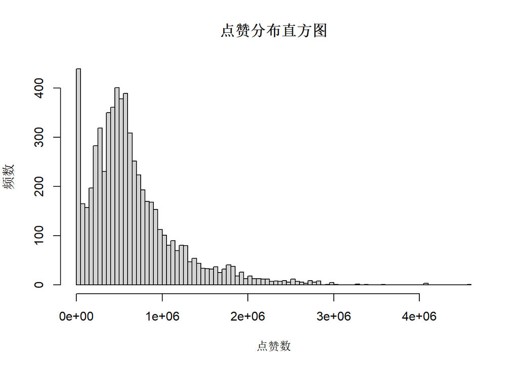

```r
hist(video$点赞数, xlab = "点赞数", ylab = "频数", main = "点赞分布直方图",  nclass = 100)
```

- 偏度：整体呈右偏态，说明大部分视频点赞较少
- 众数：众数在范围最左，可能对应低质量视频，它们数量多、点赞数几乎没有

### 2.

利用数据集中的发布时间变量，提取小时变量，命名为hour。使用折线图展示不同小时发布的短视频点赞数的差异，并进行适当解读

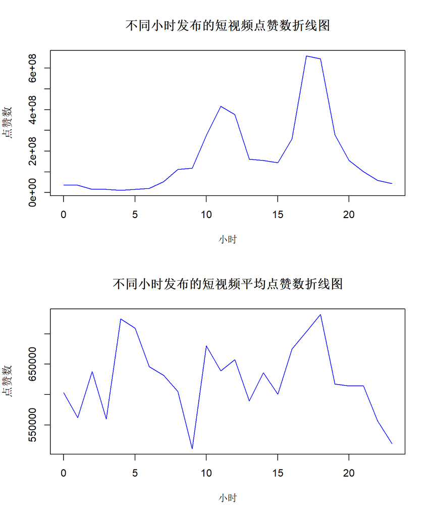

```r
video$hour <- as.integer(format(video$发布时间, format = "%H"))

# 创建画布，设置为上下排列
par(mfrow = c(2, 1))

# 使用 aggregate() 函数对数据进行按小时加和
agg_data_sum <- aggregate(点赞数 ~ hour, data = video, FUN = sum)

# 绘制合并后的折线图
plot(agg_data_sum$hour, agg_data_sum$点赞数, type = "l", col = "blue", xlab = "小时", ylab = "点赞数", main = "不同小时发布的短视频点赞数折线图")

# 使用 aggregate() 函数对数据进行按小时平均
agg_data_mean <- aggregate(点赞数 ~ hour, data = video, FUN = mean)

# 绘制合并后的折线图
plot(agg_data_mean$hour, agg_data_mean$点赞数, type = "l", col = "blue", xlab = "小时", ylab = "点赞数", main = "不同小时发布的短视频平均点赞数折线图")
```

可见大约4点和18点左右发布的视频平均点赞数最多，但从总量上来说18点左右最多而11点左右次之。综合两张子图，根据某小时的点赞数=视频发布量*平均点赞数，可知18点发布量和平均点赞都是最高的，4点平均点赞高但视频发布量少，11点平均点赞量一般但发布量高。  
但可能从根源来看，观看人数多且点赞欲望高的时段总的点赞数才会多，而与小时内视频发布量无关

### 3.

请使用分组箱线图对比不同类别的视频的点赞数差异，并进行适当解读

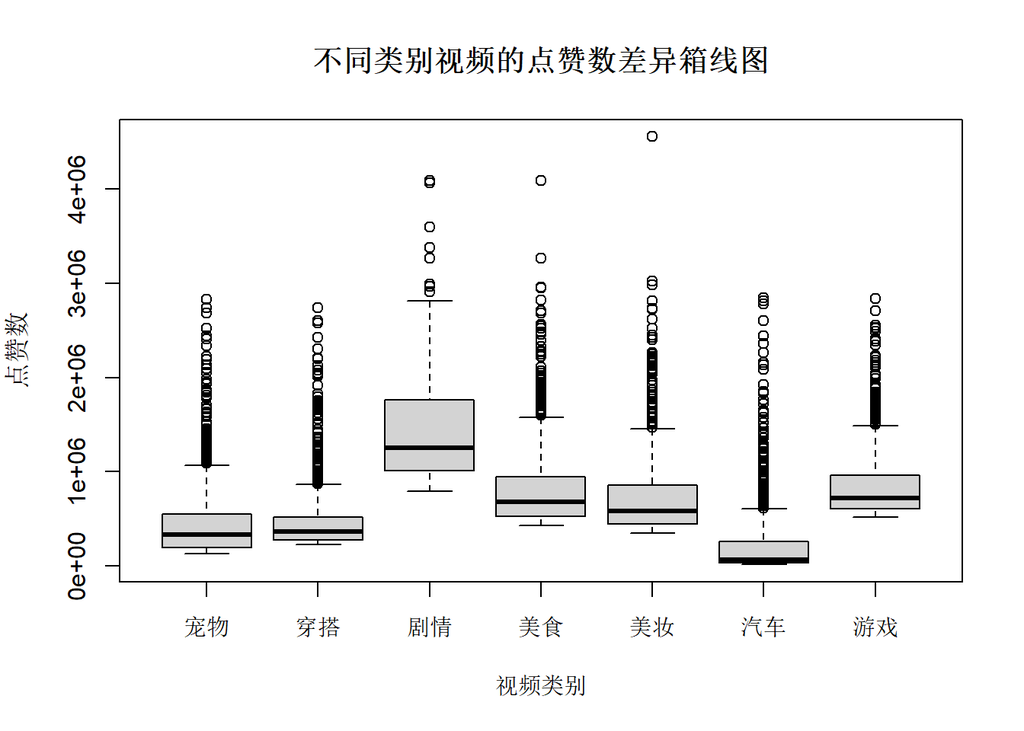

```r
boxplot(点赞数 ~ 类别, data = video,
        main = "不同类别视频的点赞数差异箱线图",
        xlab = "视频类别",
        ylab = "点赞数")
```

- 离散程度：剧情类视频的点赞数差异最大，可能说明存在明显的质量差异
- 偏度：各类别视频都呈现右偏态，说明点赞数较少的视频占大多数
- 均值：剧情类视频平均点赞数最高，而汽车类最少，这反映了观众的喜好

## 3.

由于汽车类短视频的点赞数远低于其他类别视频，对非汽车类数据进行线性回归建模分析。首先提取非汽车类数据命名为video1。再将视频发布时间分为6个时段：“20:00-次日5:59”、“6:00-8:59”、“9:00-11:59”、“12:00-13:59”、“14:00-16:59”、“17:00-19:59”，分别命名为“夜间”“早间”“上午”“中午”“下午”“傍晚”，将该变量命名为“视频发布时间”。

```r
video1 <- subset(video, 类别 != "汽车")
video1$视频发布时间 <- cut(video1$发布时间,
                            breaks = c(as.POSIXct("00:00:00", format = "%H:%M:%S"),
                                       as.POSIXct("06:00:00", format = "%H:%M:%S"),
                                       as.POSIXct("09:00:00", format = "%H:%M:%S"),
                                       as.POSIXct("12:00:00", format = "%H:%M:%S"),
                                       as.POSIXct("14:00:00", format = "%H:%M:%S"),
                                       as.POSIXct("17:00:00", format = "%H:%M:%S"),
                                       as.POSIXct("20:00:00", format = "%H:%M:%S"),
                                       as.POSIXct("24:00:00", format = "%H:%M:%S")),
                            labels = c("夜间", "早间", "上午", "中午", "下午", "傍晚", "夜间"),
                            include.lowest = TRUE)
```

建立点赞数的双对数线性回归模型，因变量为对数点赞数，自变量包括：视频发布时段（基准组：夜间）、对数分享数、对数评论数、时长、类别（基准组：宠物）、标题字数，并对结果进行适当解读

```r
model <- lm(log(点赞数) ~ 视频发布时间 + log(分享数) + log(评论数) + 时长 + 类别 + 标题字数, data = video1)
summary(model)
```

```
##
## Call:
## lm(formula = log(点赞数) ~ 视频发布时间 + log(分享数) +
##     log(评论数) + 时长 + 类别 + 标题字数, data = video1)
##
## Residuals:
##      Min       1Q   Median       3Q      Max
## -1.34324 -0.26640 -0.02106  0.24316  1.99196
##
## Coefficients:
##                   Estimate Std. Error t value Pr(>|t|)
## (Intercept)      9.8739188  0.0554695 178.006  < 2e-16 ***
## 视频发布时间早间 0.0053859  0.0280683   0.192  0.84784
## 视频发布时间上午 0.0164556  0.0191837   0.858  0.39104
## 视频发布时间中午 0.0322605  0.0208420   1.548  0.12172
## 视频发布时间下午 0.0169830  0.0208697   0.814  0.41582
## 视频发布时间傍晚 0.0444631  0.0172855   2.572  0.01013 *
## log(分享数)      0.0995106  0.0042575  23.373  < 2e-16 ***
## log(评论数)      0.2301533  0.0061970  37.140  < 2e-16 ***
## 时长             0.0027966  0.0003400   8.227 2.39e-16 ***
## 类别穿搭         0.0290268  0.0178615   1.625  0.10420
## 类别剧情         0.8239373  0.0255712  32.221  < 2e-16 ***
## 类别美食         0.4237840  0.0185328  22.867  < 2e-16 ***
## 类别美妆         0.3423557  0.0182776  18.731  < 2e-16 ***
## 类别游戏         0.5392600  0.0181481  29.714  < 2e-16 ***
## 标题字数         0.0013278  0.0004022   3.301  0.00097 ***
## ---
## Signif. codes:  0 '***' 0.001 '**' 0.01 '*' 0.05 '.' 0.1 ' ' 1
##
## Residual standard error: 0.39 on 5385 degrees of freedom
## Multiple R-squared:  0.6178, Adjusted R-squared:  0.6168
## F-statistic: 621.6 on 14 and 5385 DF,  p-value: < 2.2e-16
```

根据估计结果，视频类型（除了穿搭区）、时长、标题字数、评论数和分享数以及是否发布于傍晚都会显著影响视频点赞数。

## 4.

对第3问中建立的模型进行模型诊断，输出结果，并进行适当解读。

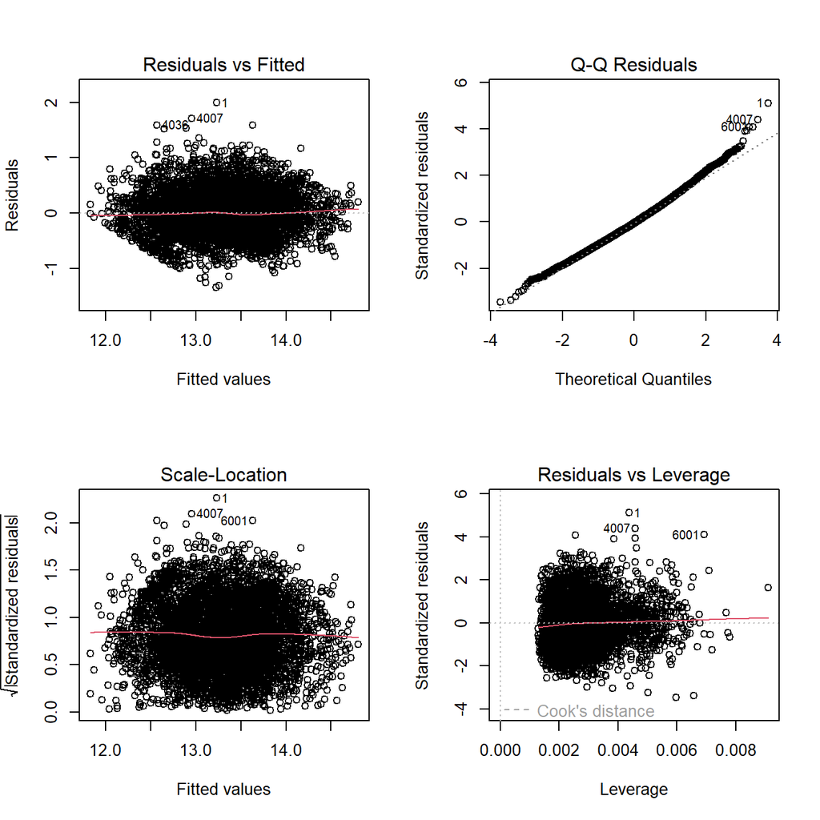

```r
par(mfrow=c(2, 2))
plot(model)
```